# Draft Preliminary Report on the Survey for the Revision of the SAA’s Principles of Archaeological Ethics

28 April, 2020

# Introduction

This draft preliminary report was prepared using data from 21 April 2020, which has 520 responses. Note that not all questions received a response, and some questions allow multiple responses. The figures show a computational analysis of the responses using reproducible quantitative methods on the survey responses.

# Uses of the current ‘Principles of Archaeological Ethics’

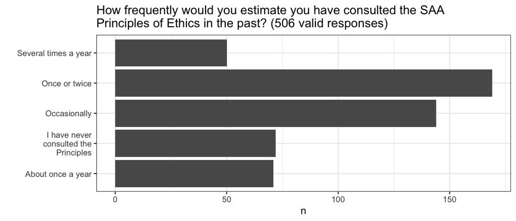

Figure 1 shows the results for multiple response question “How have you used the SAA Principles of Ethics?”. The horizontal bar plot on the left side indicates the total number of responses for each option, either individually or in any combination with other options. The vertical bar plot on the right shows the number of responses for each option by the specific combination of one option with other options. This allows us to see what combinations of options are common in the responses.

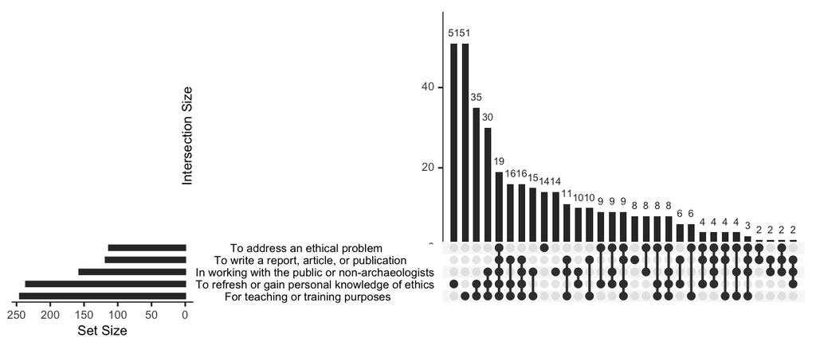

Figure 1: How have you used the SAA Principles of Ethics?… (1094 selections in 520 responses)

## Consulting other codes of ethics

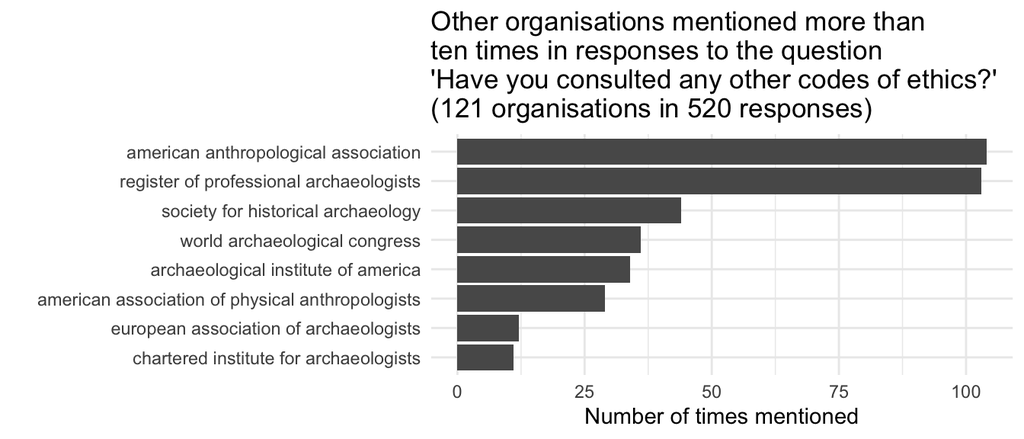

Figure 2: Other organisations mentioned more than ten times in responses to the question ‘Have you consulted any other codes of ethics?’

# Feedback on the current nine “Principles of Archaeological Ethics”

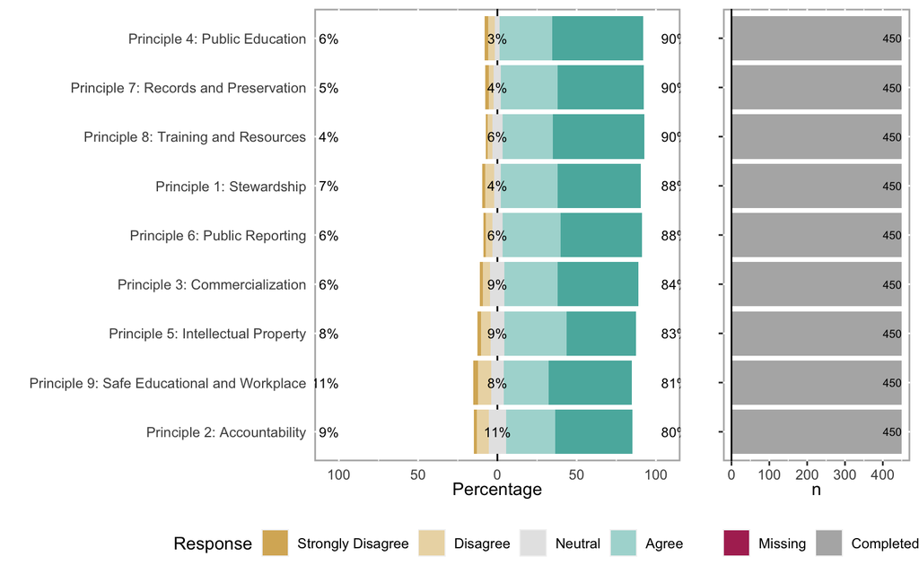

Figure 3: Plot of responses to the individual Likert scale questions about the current nine Principles

## General observations on the current nine Principles

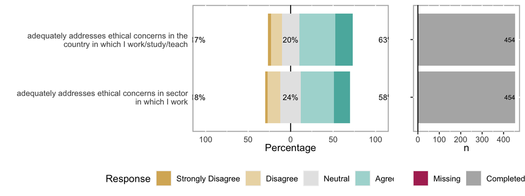

Figure 4: Plot of responses to the Likert scale questions about general observations on the current nine Principles

## Feedback on the future of ethics and the SAA

### Responses to the question “What do you see as being the primary ethical concerns in the field today?”

We use a word cloud to visualize the most frequently used words in the responses. The network plot shows how frequently used words co-occur with each other. The topic plot shows a computational model of topics present in the responses. It indicates which topics are most abundant in the responses.

A topic model is a statistical analysis of text that assumes there are k topics present in all the responses (we have to choose this number in advance, we use methods to estimate it). It assumes that every unique word in the text has a certain probability that it will appear in each topic. Computing these probability distributions is an iterative process, so each time we run the code we get slightly different combinations of words in the topics. A ‘topic’ then, is a distribution of all the unique words in the text, and one topic is different from another topic by the probability distributions of the unique words. One word can have a high probability of appearing in multiple topics, that’s why we see some duplication of words in different topics in the bar plot. The highest probability words for each topic are shown in the bar plot. Some of our topics are a bit ‘noisy’, and not highly distinctive or easily interpretable, this might be improved with some further tuning. This probabilistic approach is an advantage over the methods used for frequency-based methods (such as the word cloud), which are simply based on counts on the unique words, and so only allows a word to have a single meaning.

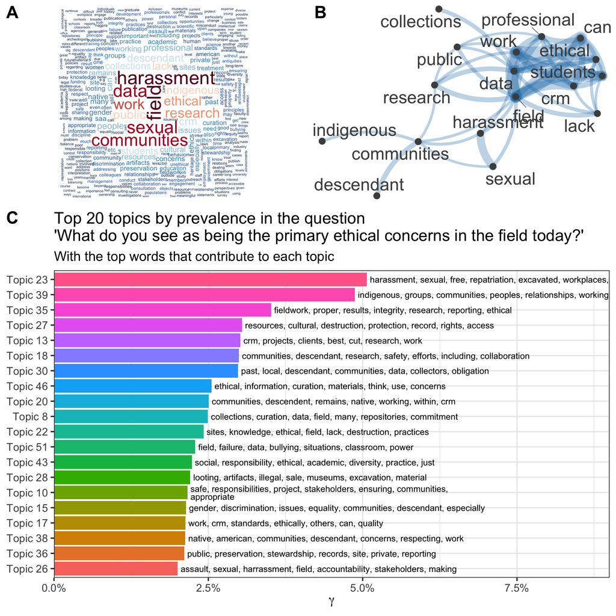

Figure 5: Visualisation of responses to ‘What do you see as being the primary ethical concerns in the field today?’ A: Word cloud of free text responses. B: Network of co-occurrences of high-frequency words. C: Topic model output.

### Responses to the question “What type of ethical document(s) do you feel would best serve the SAA membership?”

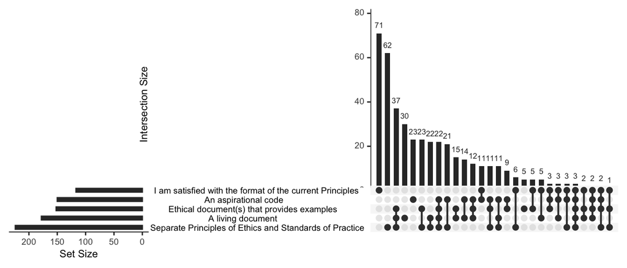

Figure 6: What type of ethical document(s) do you feel wo… (905 selections in 520 responses)

### Responses to the question “What should be the purpose of the SAA’s ethical document?”

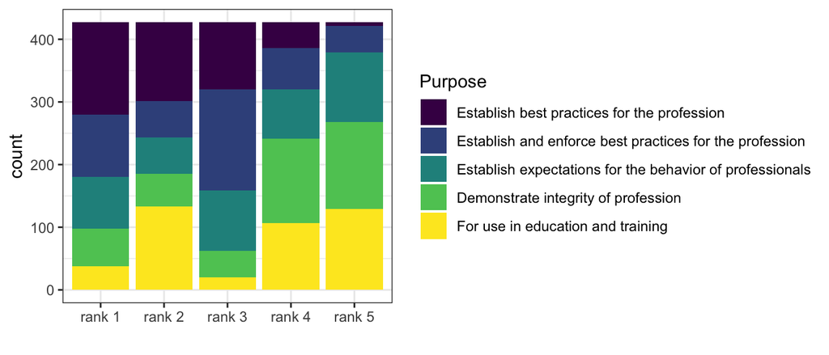

Figure 7: Plot showing the abundance of each option in each of the five ranking positions for the question ‘What should be the purpose of the SAA’

# Demographics of respondants

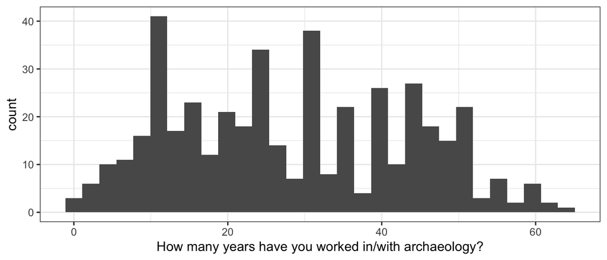

[figure not shown]